# Attrition Classification

Syed Ehraaz Atif

2024-05-15

```r
library(e1071)
```

This dataset was obtained from: “https://www.kaggle.com/datasets/sakshigoyal7/credit-card-customers”. The objective of the dataset is to figure out why customers are leaving (attriting), and what could be done to decrease the number of customers leaving.  
Here are the variables in the dataset, with necessary explanations:  
1) Attrition_Flag -> whether a customer has churned or not  
2) Customer_Age  
3) Gender  
4) Depdendent_Count -> number of dependents of customer  
5) Education_Level  
6) Marital_Status  
7) Income_Category  
8) Card_Category -> what type of card the customer has with the bank  
9) Months_on_book  
10) Total_Relationship_Count -> total number of relationships the customer has; what defines a “relationship” is unfortunately not mentioned in the metadata  
11) Months_Inactive_12_mon  
12) Contacts_Count_12_mon -> number of times customer has contacted the bank in the past 12 months  
13) Credit_Limit  
14) Total_Revolving_Bal  
15) Avg_Open_To_Buy  
16) Total_Amt_Chng_Q4_Q1  
17) Total_Trans_Amt  
18) Total_Trans_Ct  
19) Total_Ct_Chng_Q4_Q1  
20) Avg_Utilization_Ratio  
21) Naive_Bayes_Classifier_Attrition_Flag_Card_Category_Contacts_Count_12_mon_Dependent_count_Education_Level_Months_Inactive_12_mon_1 -> previous person’s work, to be removed  
23) Naive_Bayes_Classifier_Attrition_Flag_Card_Category_Contacts_Count_12_mon_Dependent_count_Education_Level_Months_Inactive_12_mon_2 -> previous person’s work, to be removed  
**DATA CLEANING**

```r
##load data
df <- read.csv("BankChurners.csv")
head(df)
```

|  | CLIENTNUM | Attrition_Flag | Customer_Age | Gender | Dependent_count | Education_Level | Marital_Status | Income_Category | Card_Category | Months_on_book | Total_Relationship_Count | Months_Inactive_12_mon | Contacts_Count_12_mon | Credit_Limit | Total_Revolving_Bal | Avg_Open_To_Buy | Total_Amt_Chng_Q4_Q1 | Total_Trans_Amt | Total_Trans_Ct | Total_Ct_Chng_Q4_Q1 | Avg_Utilization_Ratio | Naive_Bayes_Classifier_Attrition_Flag_Card_Category_Contacts_Count_12_mon_Dependent_count_Education_Level_Months_Inactive_12_mon_1 | Naive_Bayes_Classifier_Attrition_Flag_Card_Category_Contacts_Count_12_mon_Dependent_count_Education_Level_Months_Inactive_12_mon_2 |
| --- | --- | --- | --- | --- | --- | --- | --- | --- | --- | --- | --- | --- | --- | --- | --- | --- | --- | --- | --- | --- | --- | --- | --- |
| 1 | 768805383 | Existing Customer | 45 | M | 3 | High School | Married | $60K - $80K | Blue | 39 | 5 | 1 | 3 | 12691 | 777 | 11914 | 1.335 | 1144 | 42 | 1.625 | 0.061 | 9.3448e-05 | 0.99991 |
| 2 | 818770008 | Existing Customer | 49 | F | 5 | Graduate | Single | Less than $40K | Blue | 44 | 6 | 1 | 2 | 8256 | 864 | 7392 | 1.541 | 1291 | 33 | 3.714 | 0.105 | 5.6861e-05 | 0.99994 |
| 3 | 713982108 | Existing Customer | 51 | M | 3 | Graduate | Married | $80K - $120K | Blue | 36 | 4 | 1 | 0 | 3418 | 0 | 3418 | 2.594 | 1887 | 20 | 2.333 | 0.000 | 2.1081e-05 | 0.99998 |
| 4 | 769911858 | Existing Customer | 40 | F | 4 | High School | Unknown | Less than $40K | Blue | 34 | 3 | 4 | 1 | 3313 | 2517 | 796 | 1.405 | 1171 | 20 | 2.333 | 0.760 | 1.3366e-04 | 0.99987 |
| 5 | 709106358 | Existing Customer | 40 | M | 3 | Uneducated | Married | $60K - $80K | Blue | 21 | 5 | 1 | 0 | 4716 | 0 | 4716 | 2.175 | 816 | 28 | 2.500 | 0.000 | 2.1676e-05 | 0.99998 |
| 6 | 713061558 | Existing Customer | 44 | M | 2 | Graduate | Married | $40K - $60K | Blue | 36 | 3 | 1 | 2 | 4010 | 1247 | 2763 | 1.376 | 1088 | 24 | 0.846 | 0.311 | 5.5077e-05 | 0.99994 |

```r
##get rid of unnecessary columns
df <- df[,-c(1,22,23)]
colnames(df)
```

```
##  [1] "Attrition_Flag"           "Customer_Age"
##  [3] "Gender"                   "Dependent_count"
##  [5] "Education_Level"          "Marital_Status"
##  [7] "Income_Category"          "Card_Category"
##  [9] "Months_on_book"           "Total_Relationship_Count"
## [11] "Months_Inactive_12_mon"   "Contacts_Count_12_mon"
## [13] "Credit_Limit"             "Total_Revolving_Bal"
## [15] "Avg_Open_To_Buy"          "Total_Amt_Chng_Q4_Q1"
## [17] "Total_Trans_Amt"          "Total_Trans_Ct"
## [19] "Total_Ct_Chng_Q4_Q1"      "Avg_Utilization_Ratio"
```

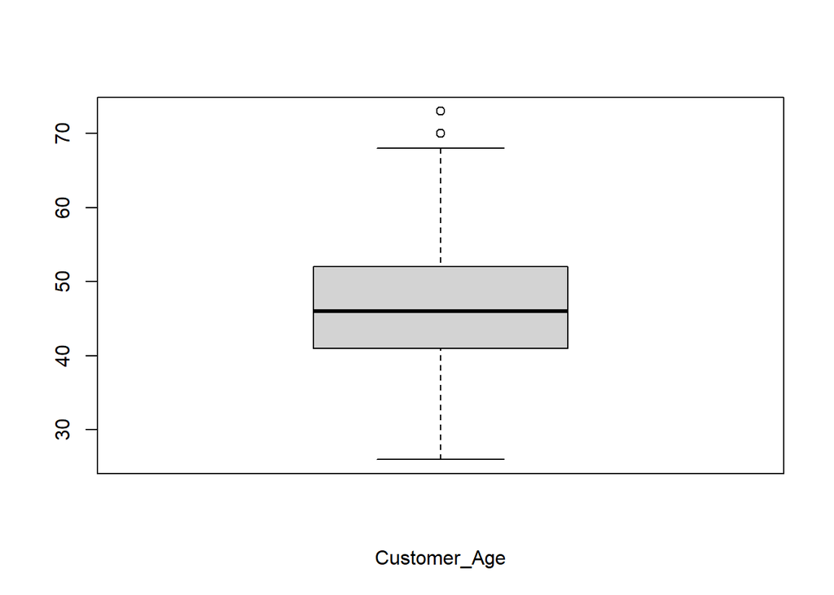

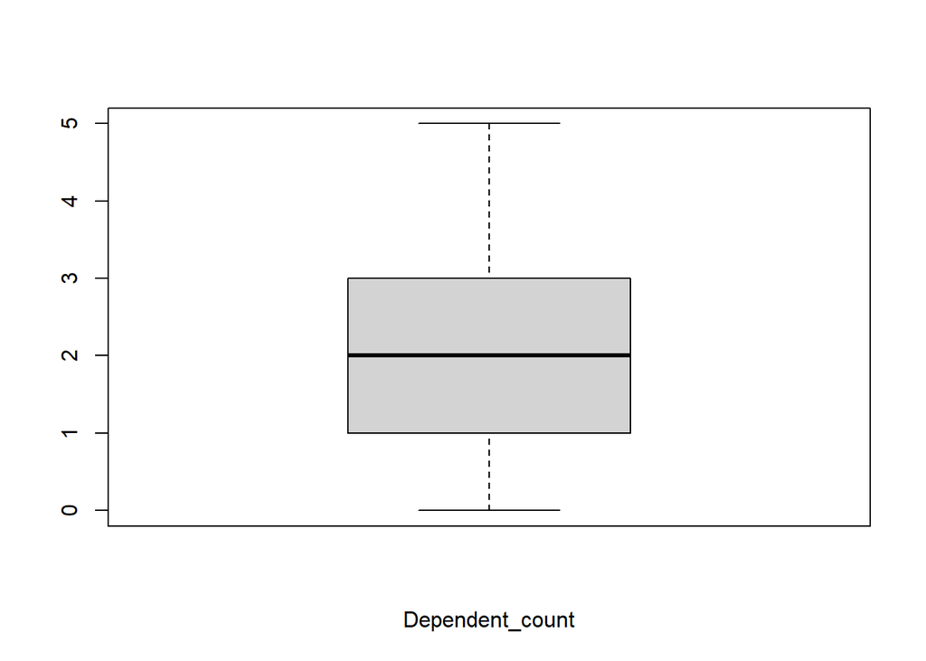

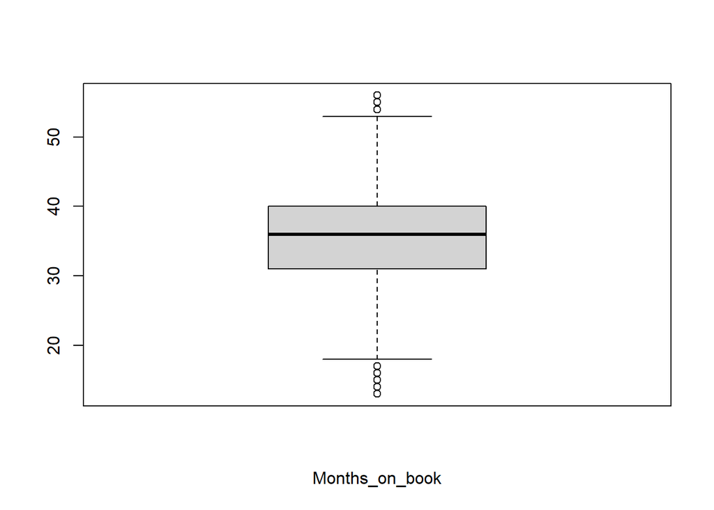

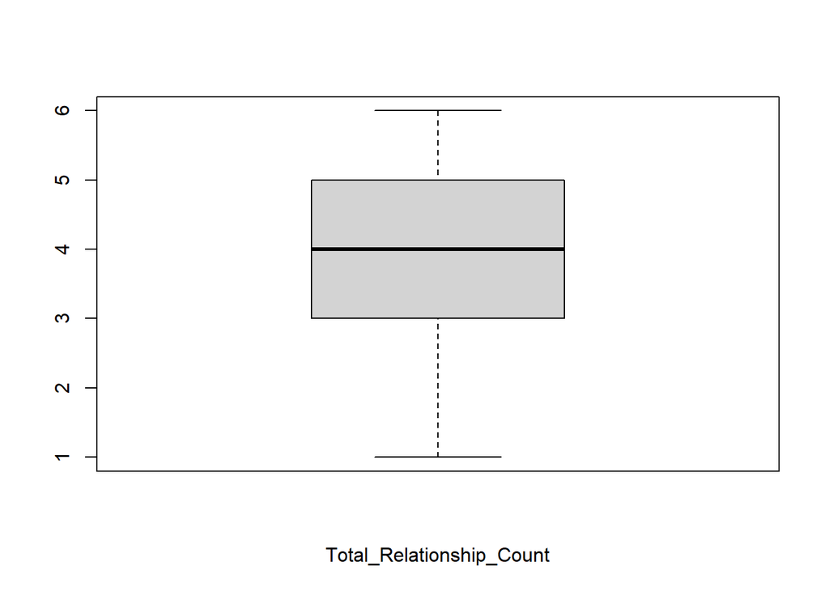

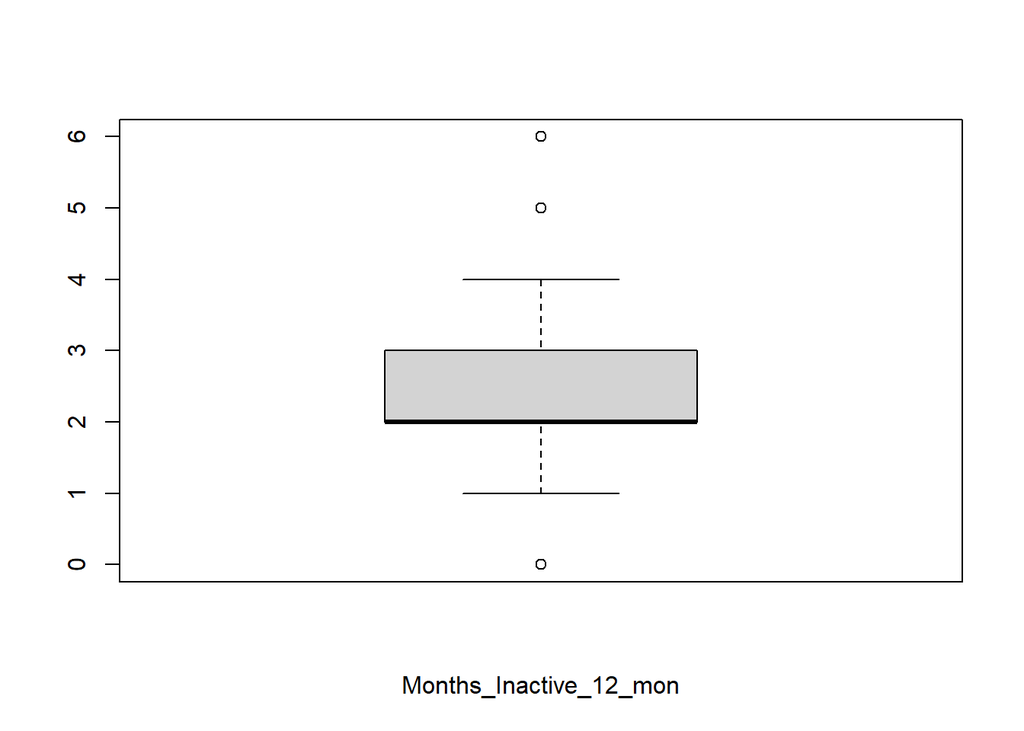

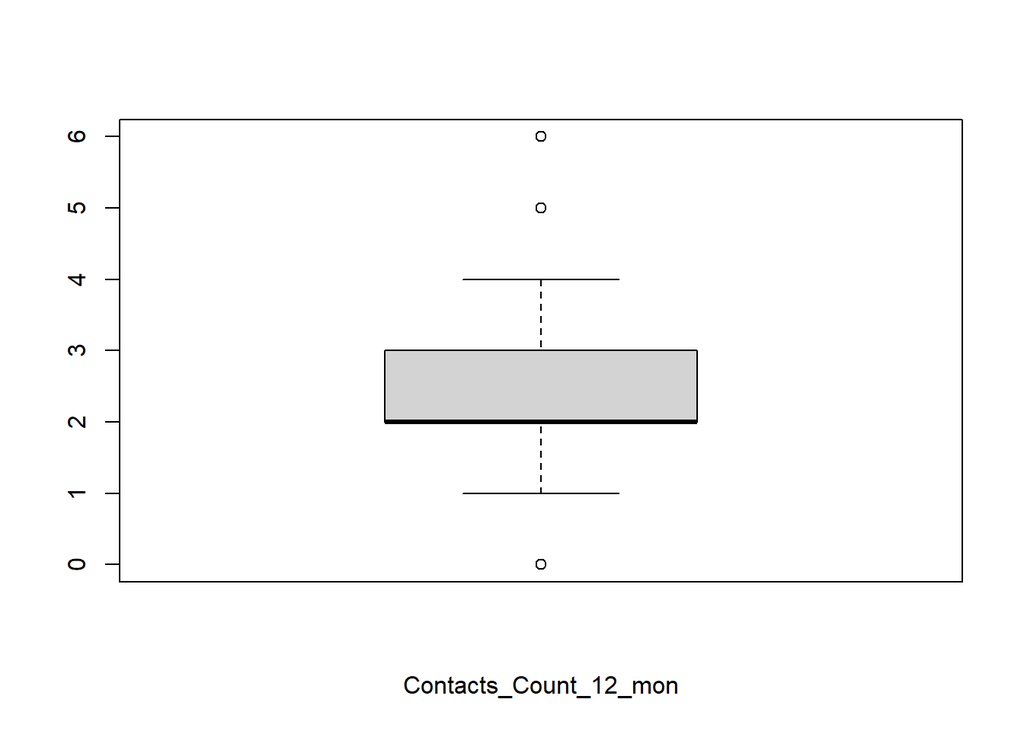

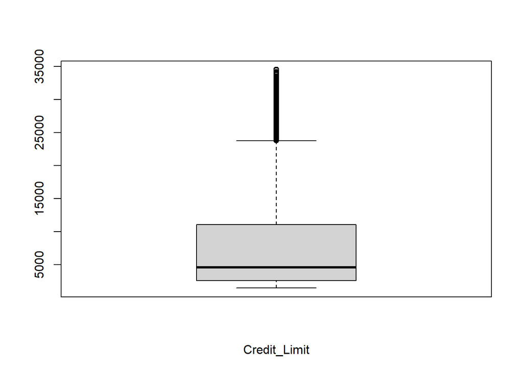

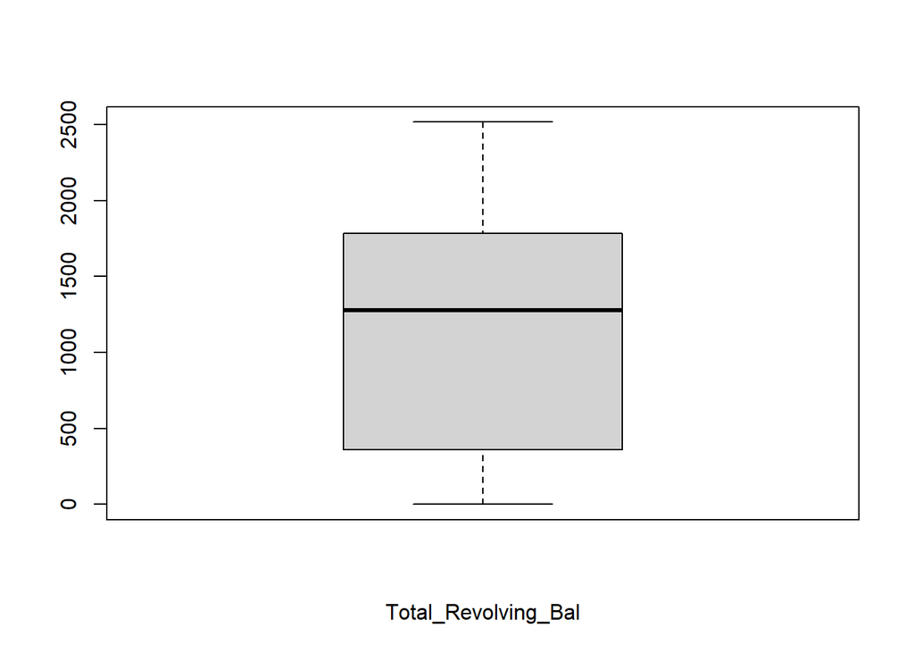

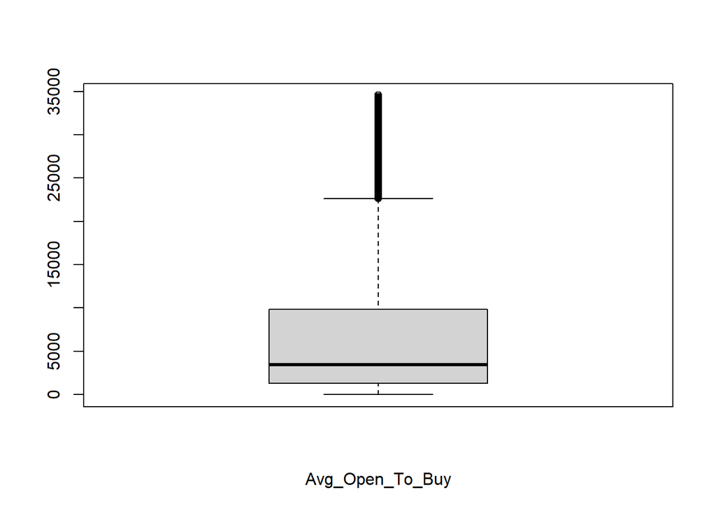

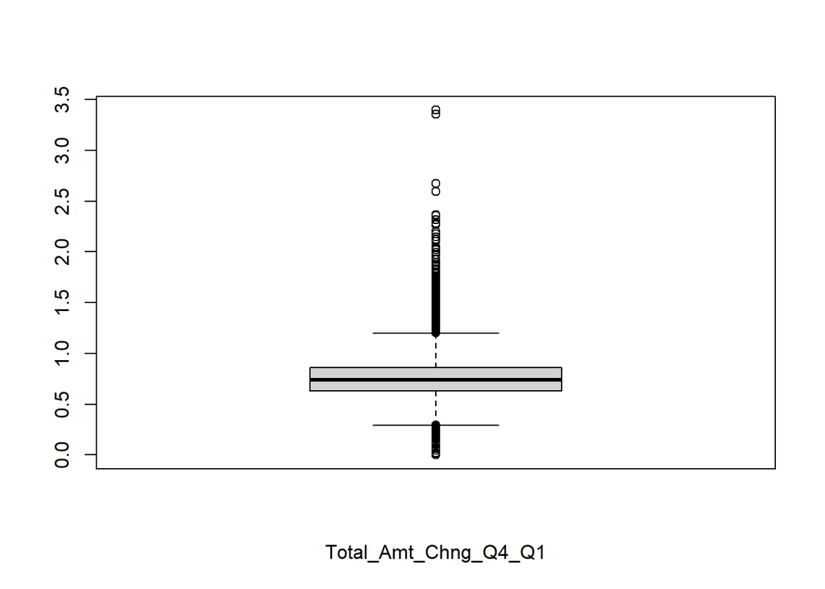

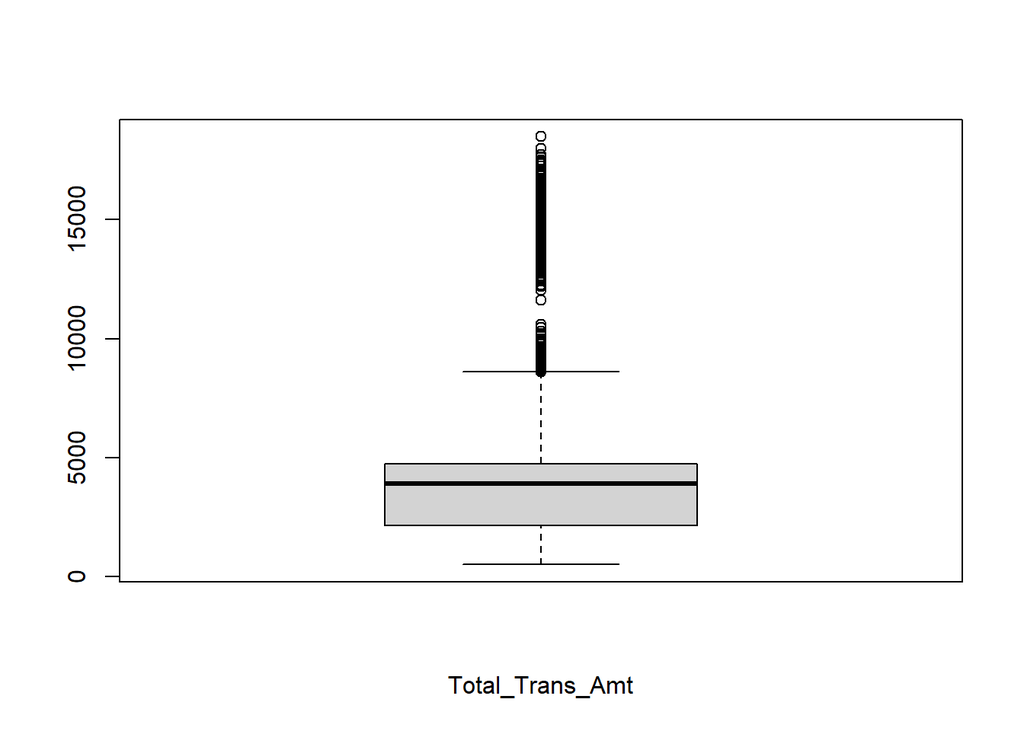

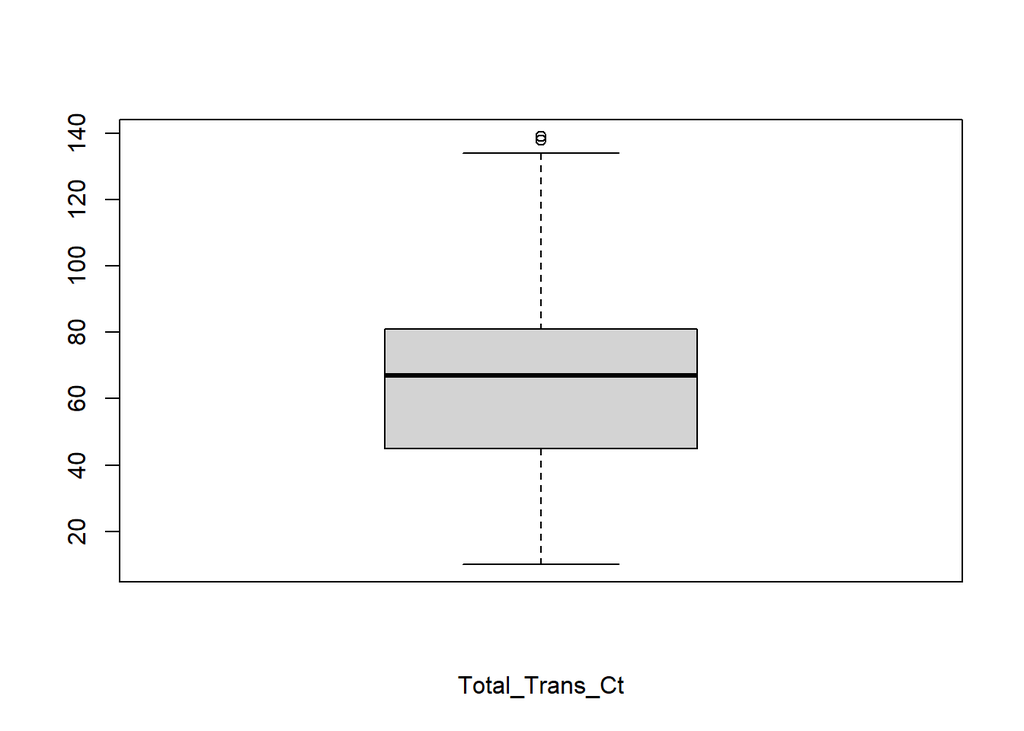

[2 more figures not shown]

```r
##inspect variables
cols <- c(2,4,9:20)
for (i in cols) {
  boxplot(df[,i], xlab=colnames(df)[i])
}
```

```r
##inspect variables
unique(df$Attrition_Flag)
```

```
## [1] "Existing Customer" "Attrited Customer"
```

```r
unique(df$Gender)
```

```
## [1] "M" "F"
```

```r
unique(df$Education_Level)
```

```
## [1] "High School"   "Graduate"      "Uneducated"    "Unknown"
## [5] "College"       "Post-Graduate" "Doctorate"
```

```r
unique(df$Marital_Status)
```

```
## [1] "Married"  "Single"   "Unknown"  "Divorced"
```

```r
unique(df$Income_Category)
```

```
## [1] "$60K - $80K"    "Less than $40K" "$80K - $120K"   "$40K - $60K"
## [5] "$120K +"        "Unknown"
```

```r
unique(df$Card_Category)
```

```
## [1] "Blue"     "Gold"     "Silver"   "Platinum"
```

Some of the categorical variables seem to have “Unknown” values, which are probably a stand-in for NA or missing values.

```r
##get dataset where each row has at least one "Unknown"
edu_unknown <- which(df$Education_Level == "Unknown")
marital_unknown <- which(df$Marital_Status == "Unknown")
income_unknown <- which(df$Income_Category == "Unknown")
rows_unknown <- unique(union(unique(union(edu_unknown, marital_unknown)), income_unknown))

length(rows_unknown)
```

```
## [1] 3046
```

There are 3046 observations with “Unknown” in at least one column. The total size of the dataset is ~10k observations. If all 3046 observations are removed, there would still be ~70% of the dataset leftover (about 7k observations), which should be more than enough to do any analysis or modeling.

```r
##take out unknowns
df2 <- df[-as.integer(rows_unknown),]
dim(df2)
```

```
## [1] 7081   20
```

```r
##convert appropriate columns to factor datatype
df2$Attrition_Flag <- factor(df2$Attrition_Flag)
df2$Gender <- factor(df2$Gender)
df2$Marital_Status <- factor(df2$Marital_Status)

df2$Education_Level <- factor(df2$Education_Level,
                              levels=c(
                                "Uneducated",
                                "High School",
                                "College",
                                "Graduate",
                                "Post-Graduate",
                                "Doctorate"
                              ), ordered=TRUE)

df2$Income_Category <- factor(df2$Income_Category,
                              levels=c(
                                "Less than $40K",
                                "$40K - $60K",
                                "$60K - $80K",
                                "$80K - $120K",
                                "$120K +"
                              ), ordered=TRUE)

df2$Card_Category <- factor(df2$Card_Category,
                            levels=c(
                              "Blue",
                              "Silver",
                              "Platinum",
                              "Gold"
                            ), ordered=TRUE)
```

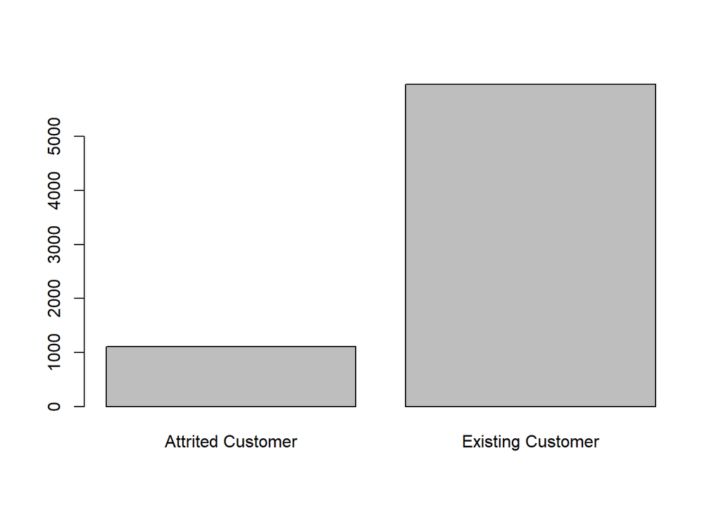

```r
##inspect variables
barplot(height=table(df2$Attrition_Flag))
```

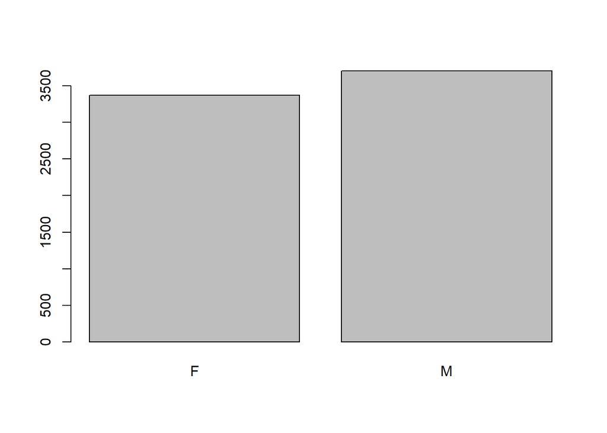

```r
barplot(height=table(df2$Gender))
```

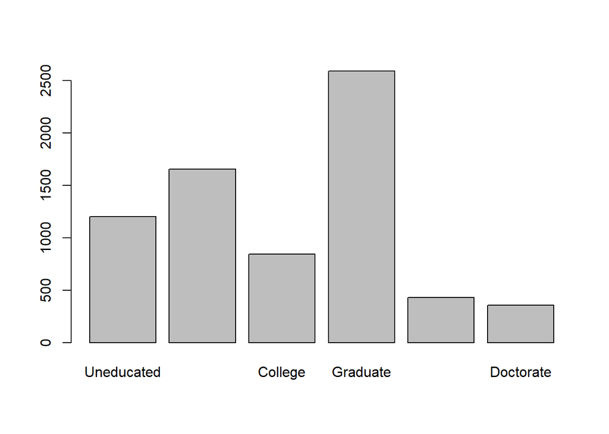

```r
barplot(height=table(df2$Education_Level))
```

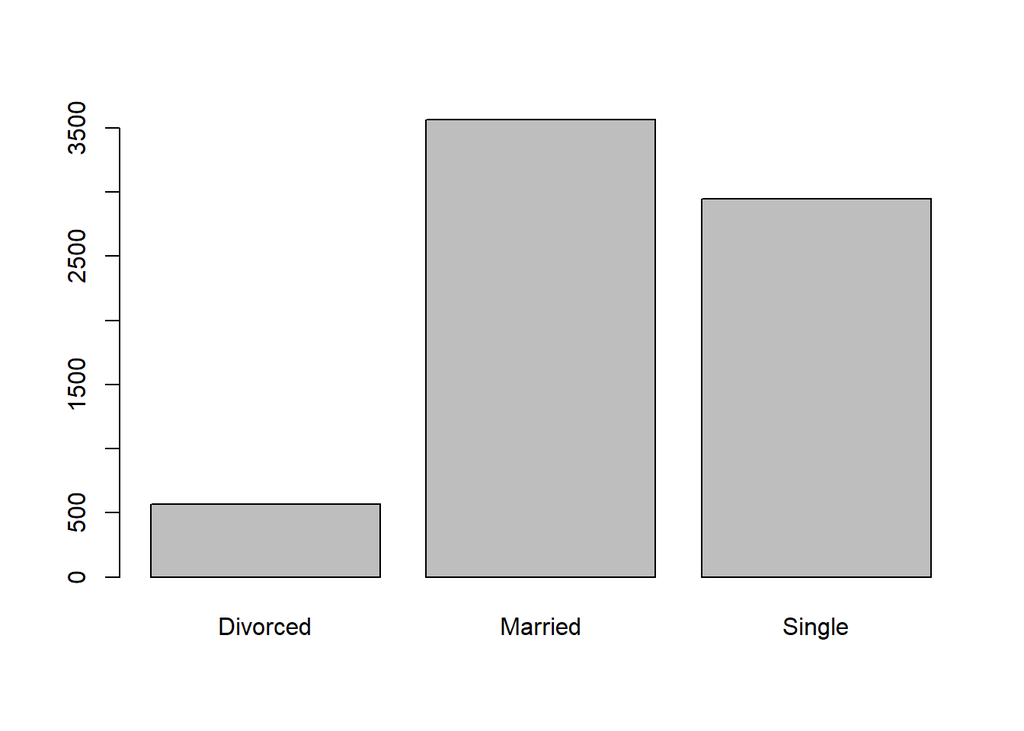

```r
barplot(height=table(df2$Marital_Status))
```

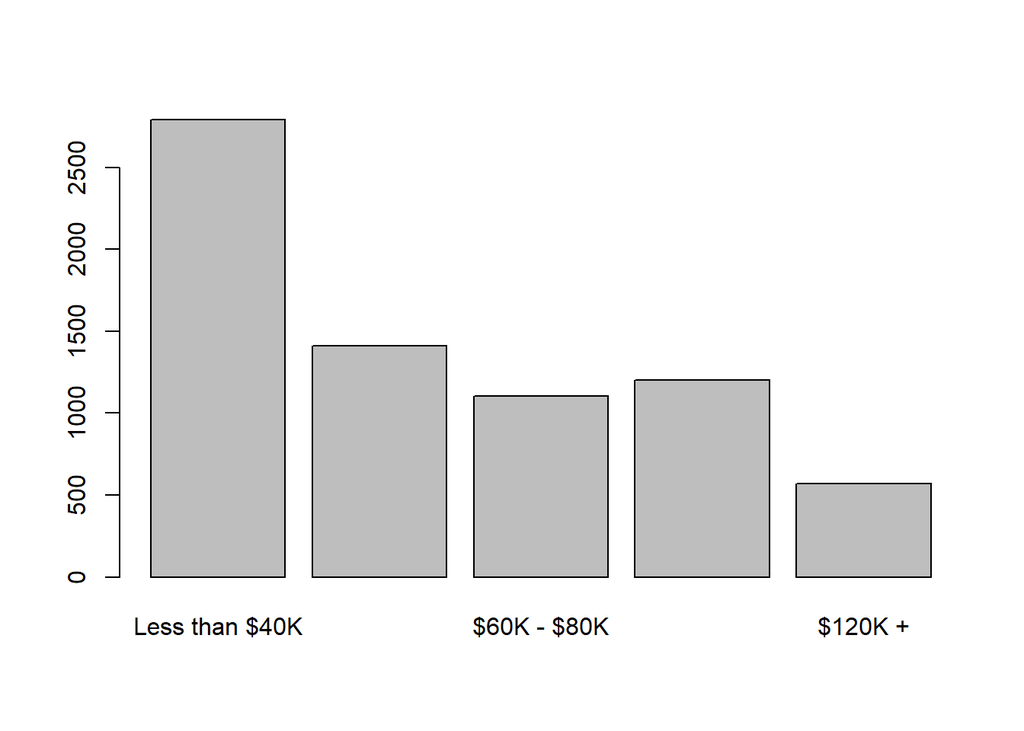

```r
barplot(height=table(df2$Income_Category))
```

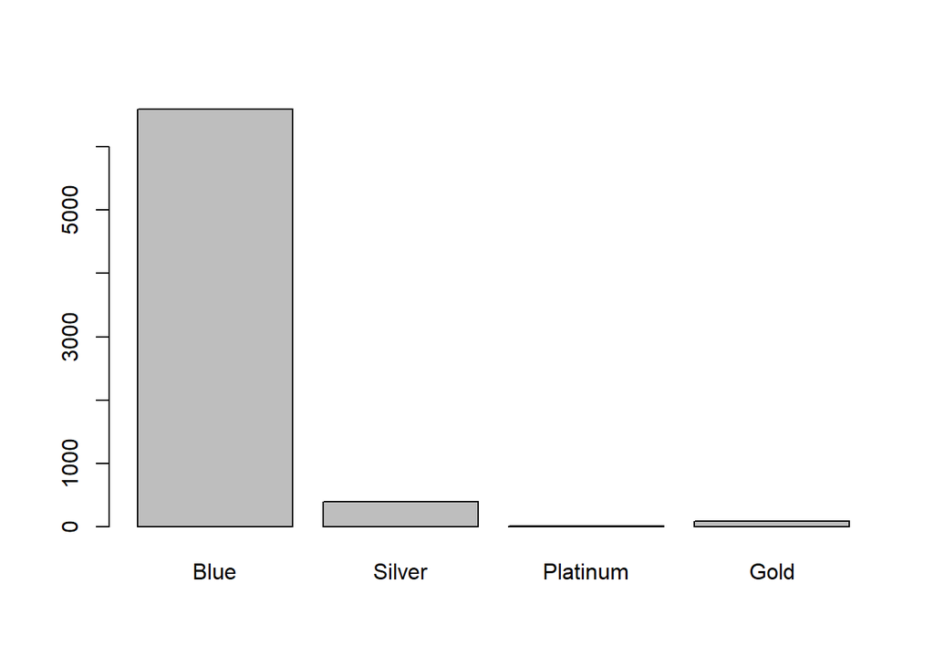

```r
barplot(height=table(df2$Card_Category))
```

Observations:  
1) Many more existing customers than attrited  
2) Very few divorced in comparison to married or single  
3) Very, very few non-blue card members  
To balance out the dataset, an equivalent number of attrited and existing customers must be sampled, as an imbalance could be problematic for any models. There should remain ~2k observations, which is a lot less than the initial 10k, but is still a sizeable amount. Additionally, the vast majority of customers have blue cards, so that variable gives negligeble information; it might be simpler to remove it entirely. Lastly, although there are imbalances in the Marital_Status variable, they are not significant enough to consider re-balancing.

```r
##balance out the dataset
set.seed(0)

##sample existing customers
attrited_customer_sample <- rownames(df2[df2$Attrition_Flag=="Attrited Customer",])
existing_customer_sample <- sample(rownames(df2[df2$Attrition_Flag=="Existing Customer",]),
                                   length(attrited_customer_sample))
sample_rows <- union(attrited_customer_sample, existing_customer_sample)
df3 <- df2[sample_rows,]

##exclude the card category
df3 <- df3[,-8]
```

**EDA**  
Now that the data is clean, we can begin to investigate relationships between the variables.

```r
##look for relationships
##keeping it commented out - interesting plots are displayed below

#for (i in 1:19) {
#  for (j in 1:19) {
#    if (i != j) {
#      plot(x=df3[,i], y=df3[,j], xlab=colnames(df3)[i], ylab=colnames(df3)[j])
#    }
#  }
#}
```

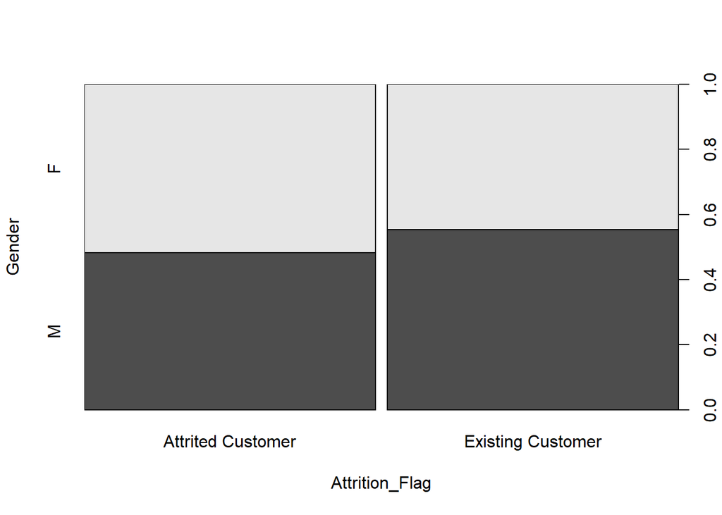

```r
##found the following relationships
plot(Gender ~ Attrition_Flag, data=df3)
```

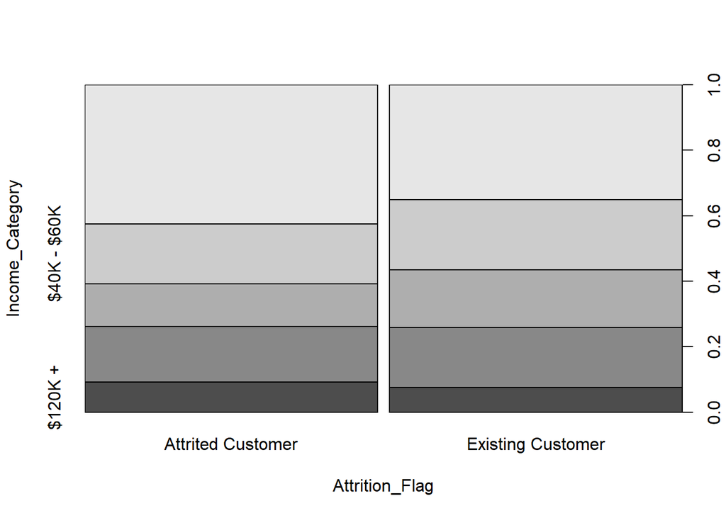

```r
plot(Income_Category ~ Attrition_Flag, data=df3)
```

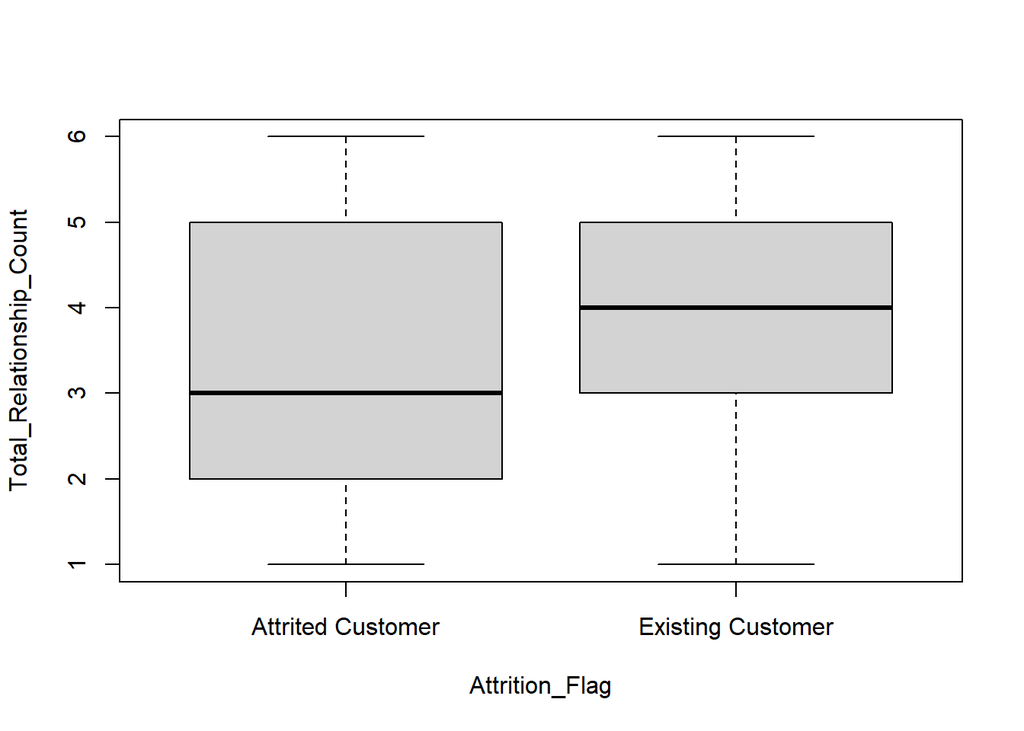

```r
plot(Total_Relationship_Count ~ Attrition_Flag, data=df3)
```

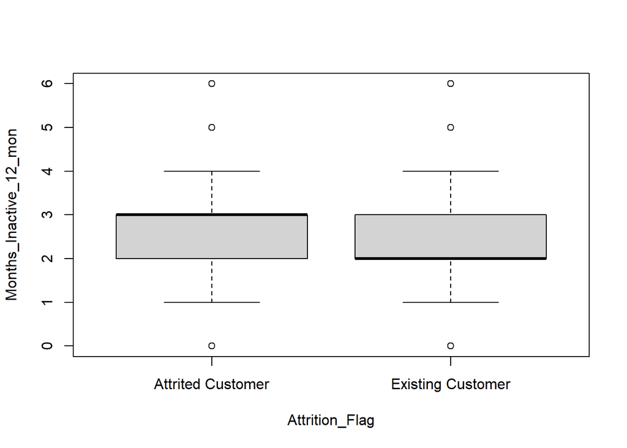

```r
plot(Months_Inactive_12_mon ~ Attrition_Flag, data=df3)
```

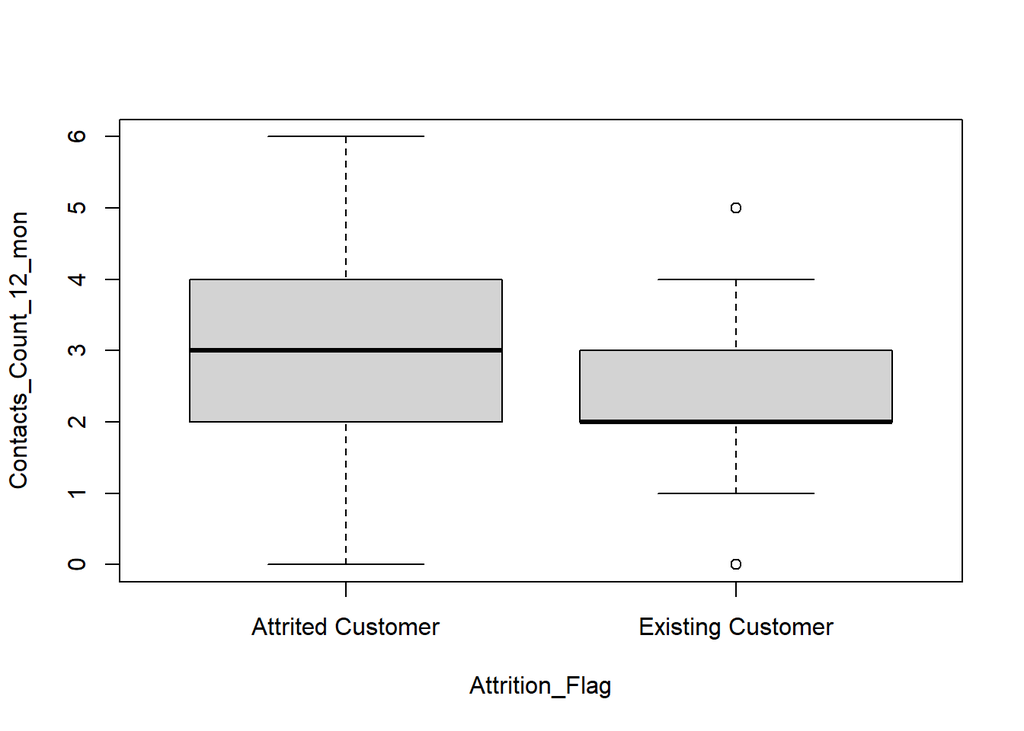

```r
plot(Contacts_Count_12_mon ~ Attrition_Flag, data=df3)
```

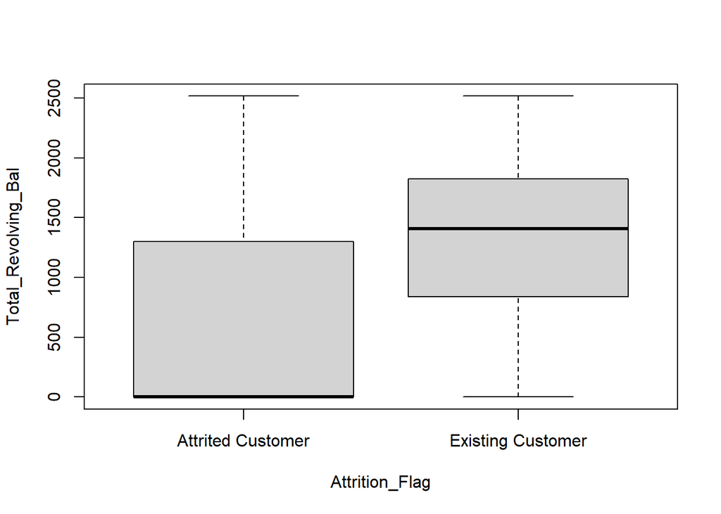

```r
plot(Total_Revolving_Bal ~ Attrition_Flag, data=df3)
```

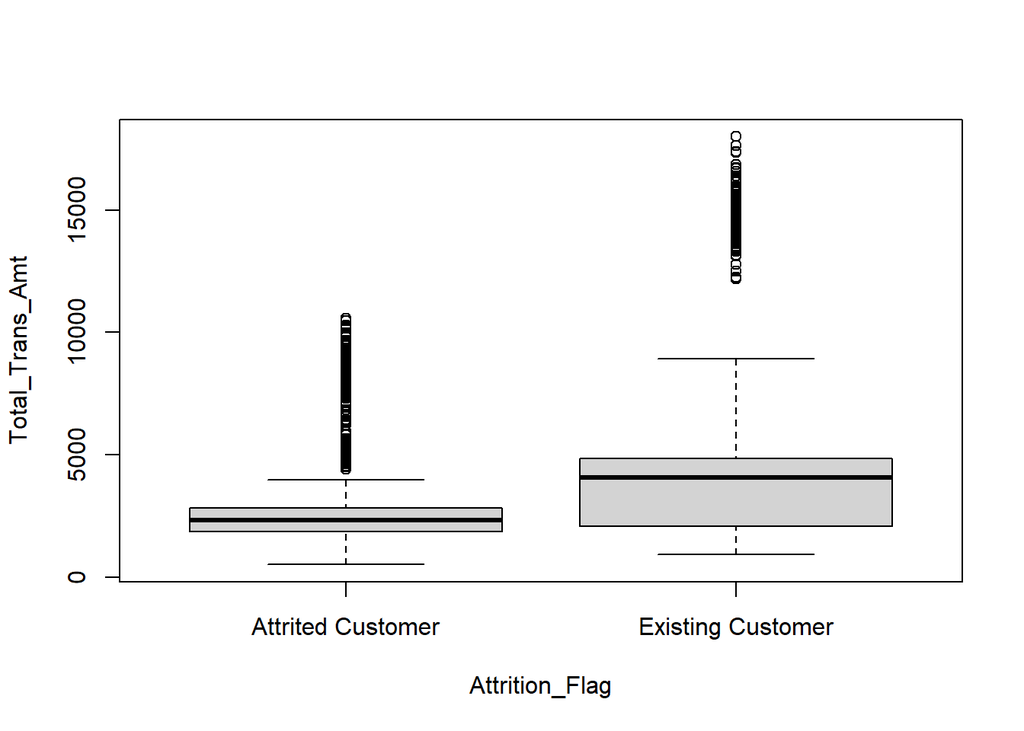

```r
plot(Total_Trans_Amt ~ Attrition_Flag, data=df3)
```

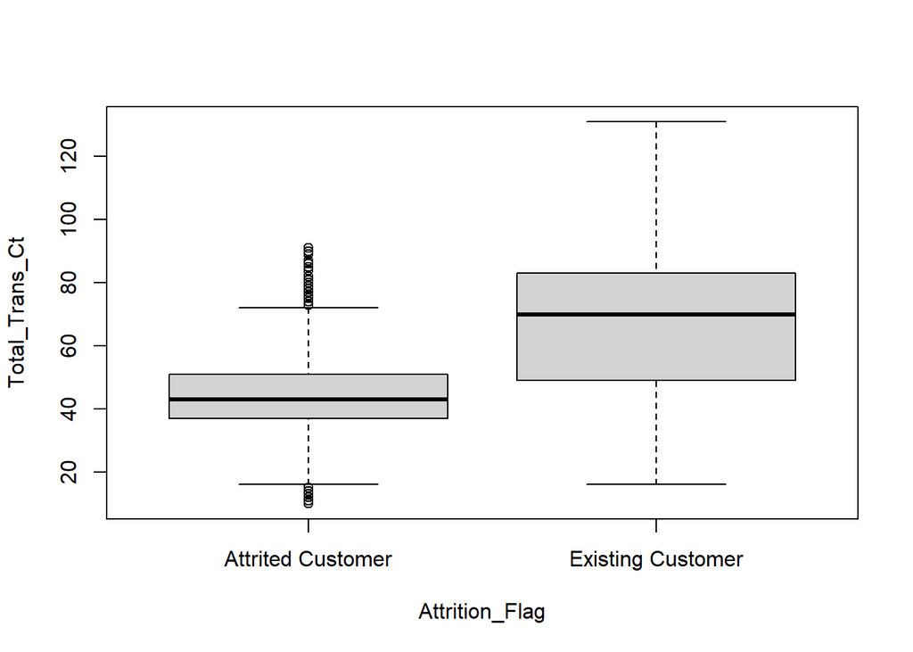

```r
plot(Total_Trans_Ct ~ Attrition_Flag, data=df3)
```

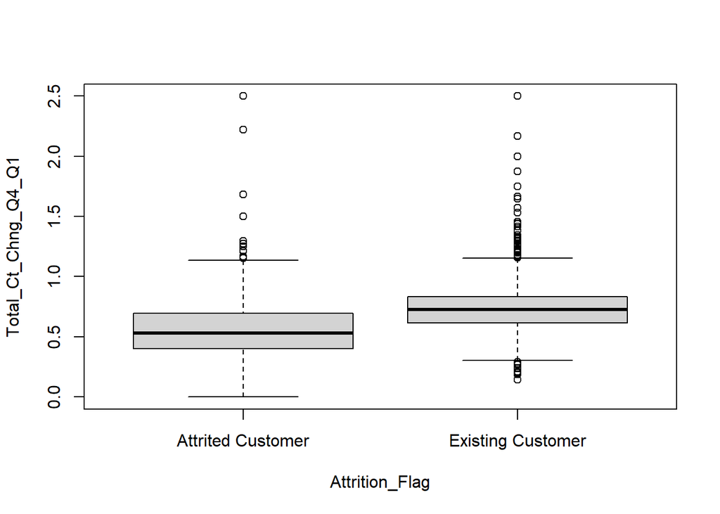

```r
plot(Total_Ct_Chng_Q4_Q1 ~ Attrition_Flag, data=df3)
```

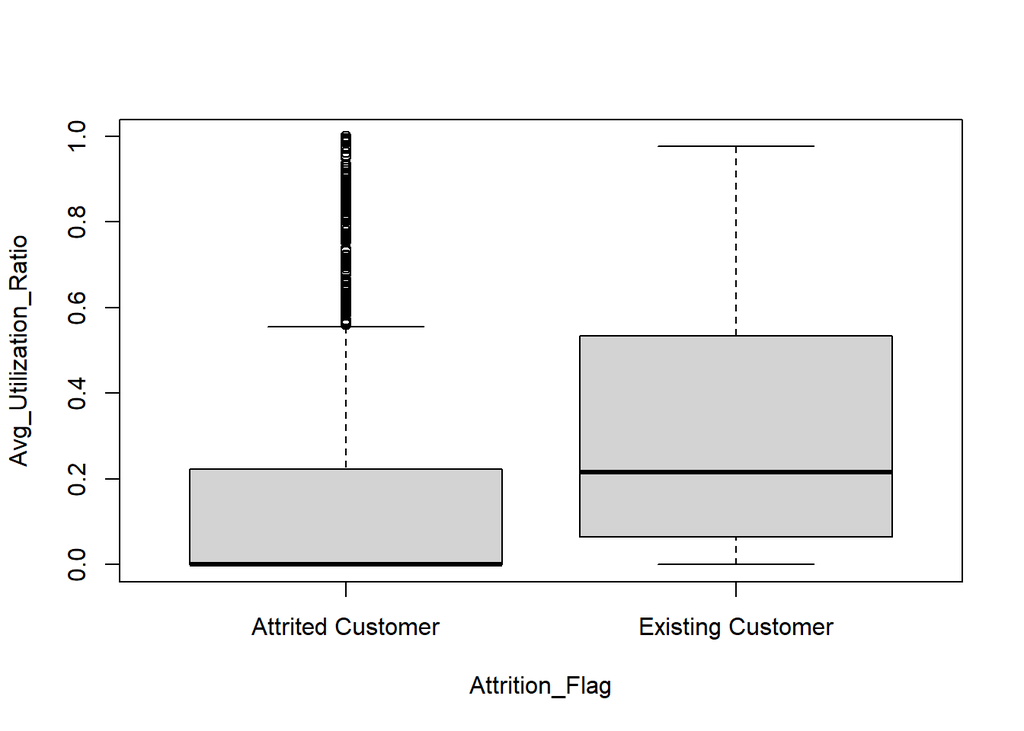

```r
plot(Avg_Utilization_Ratio ~ Attrition_Flag, data=df3)
```

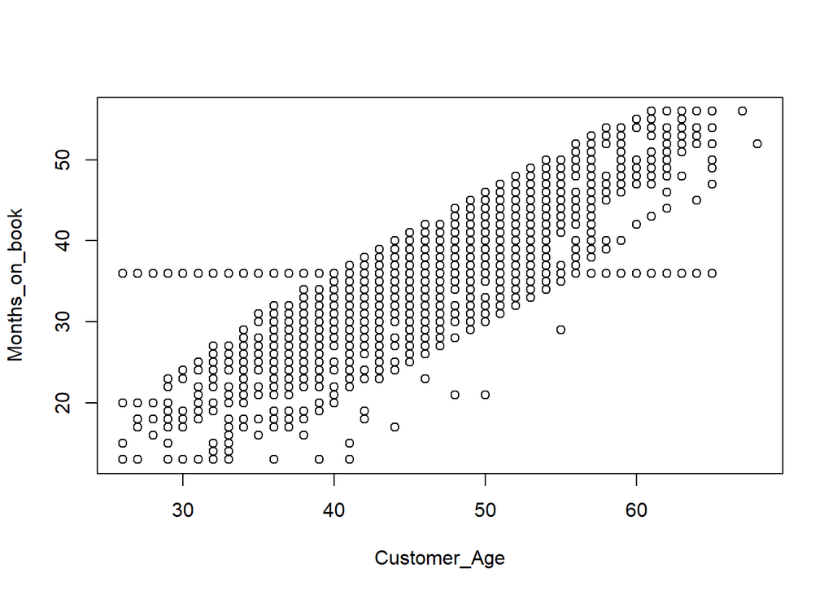

```r
plot(Months_on_book ~ Customer_Age, data=df3)
```

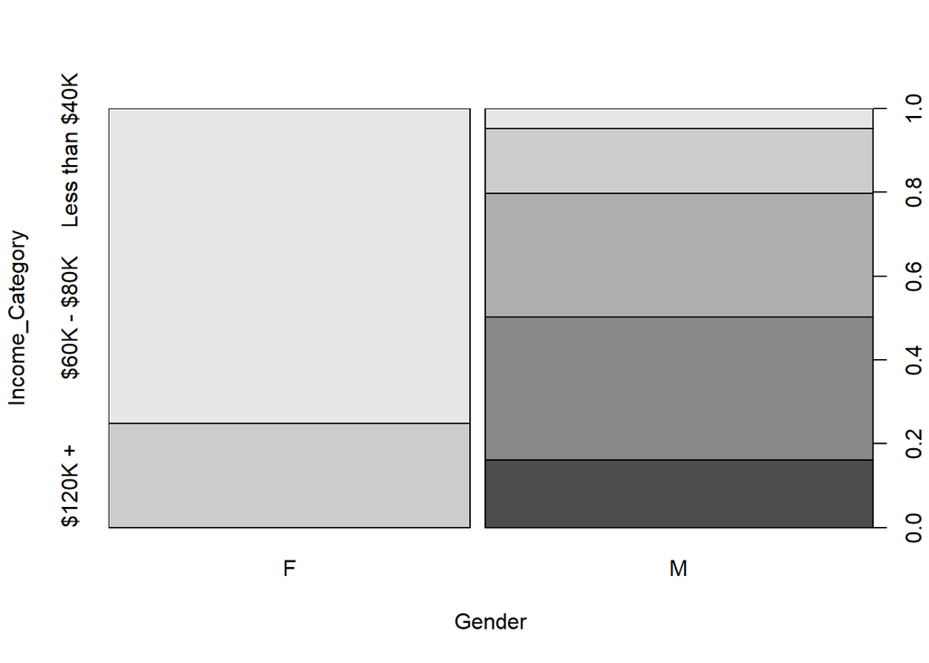

```r
plot(Income_Category ~ Gender, data=df3)
```

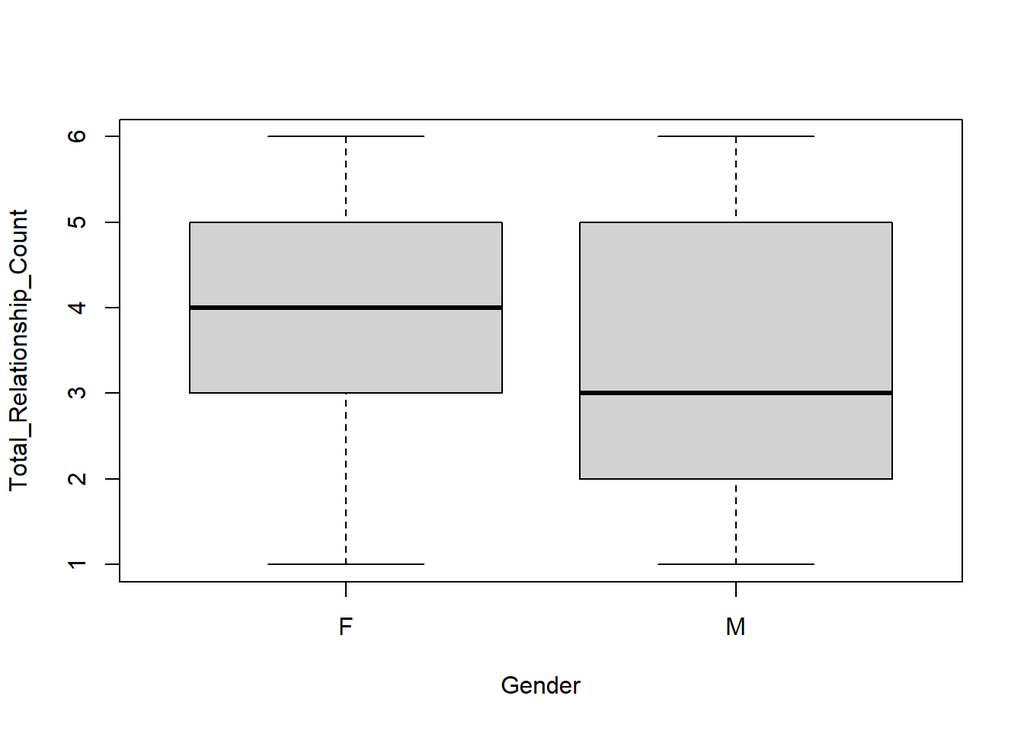

```r
plot(Total_Relationship_Count ~ Gender, data=df3)
```

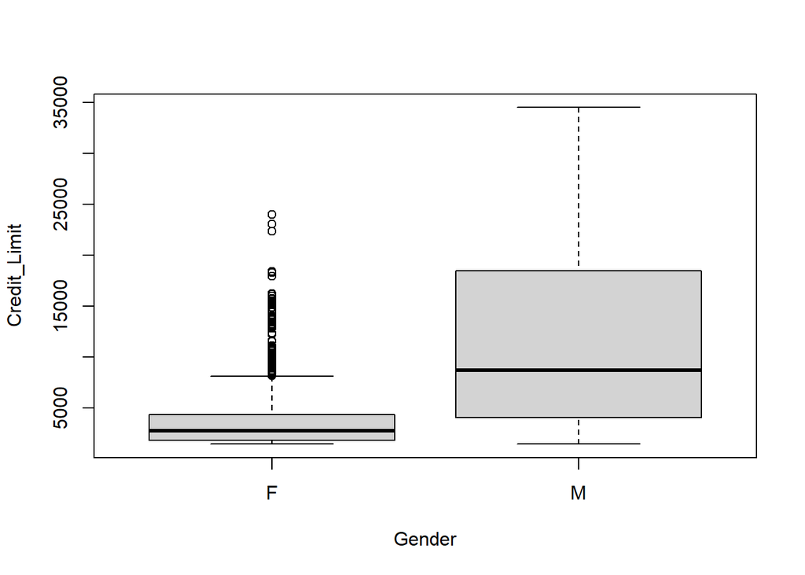

```r
plot(Credit_Limit ~ Gender, data=df3)
```

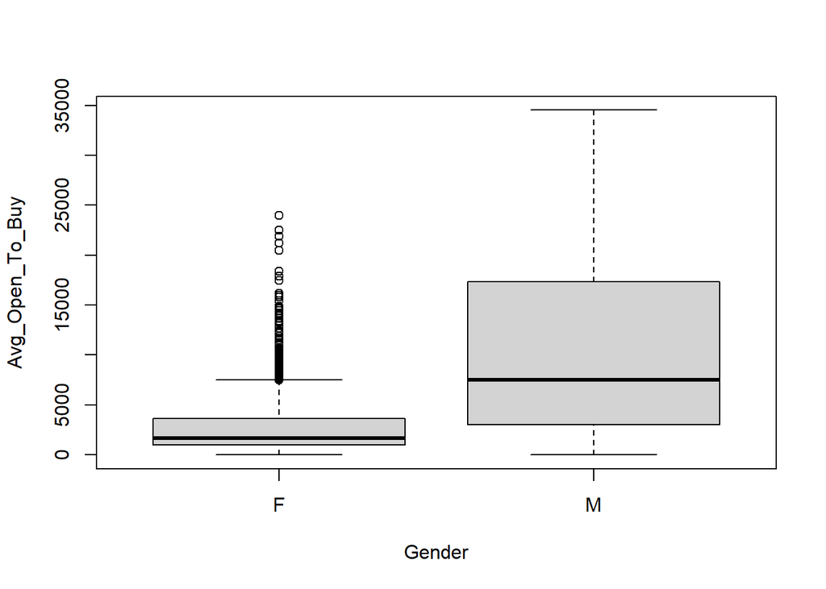

```r
plot(Avg_Open_To_Buy ~ Gender, data=df3)
```

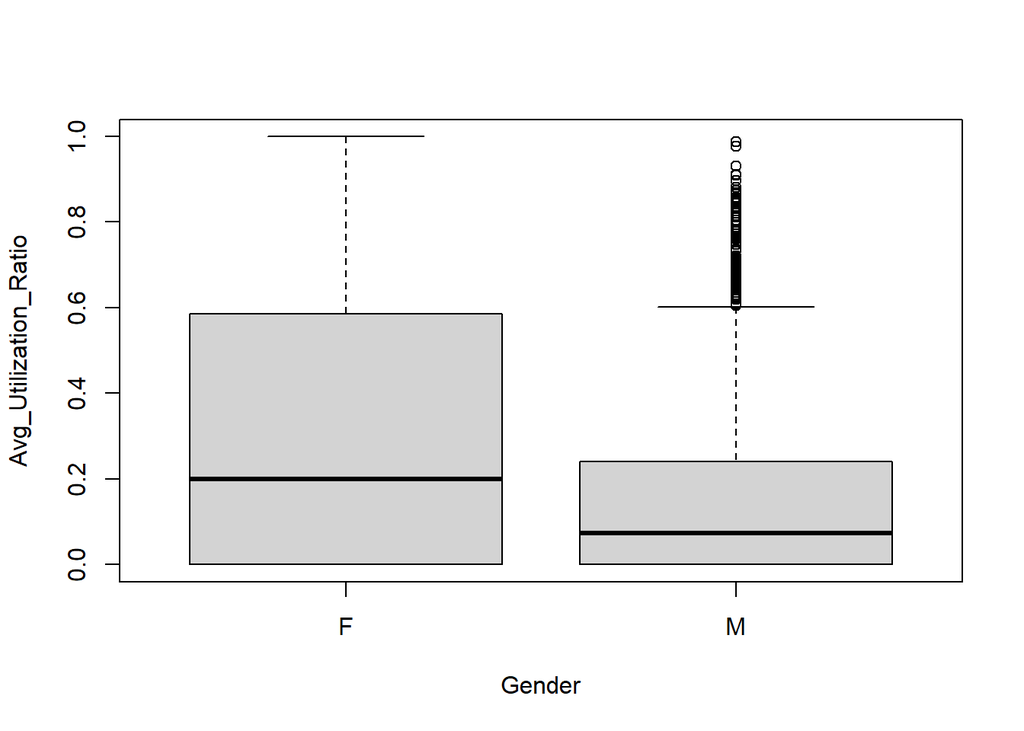

```r
plot(Avg_Utilization_Ratio ~ Gender, data=df3)
```

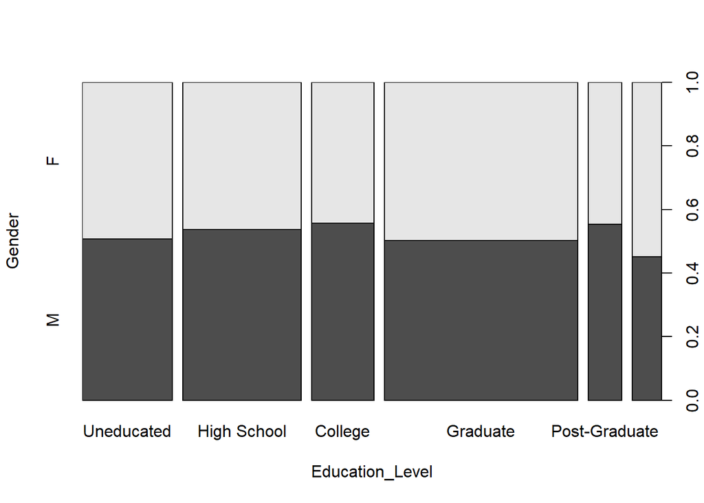

```r
plot(Gender ~ Education_Level, data=df3)
```

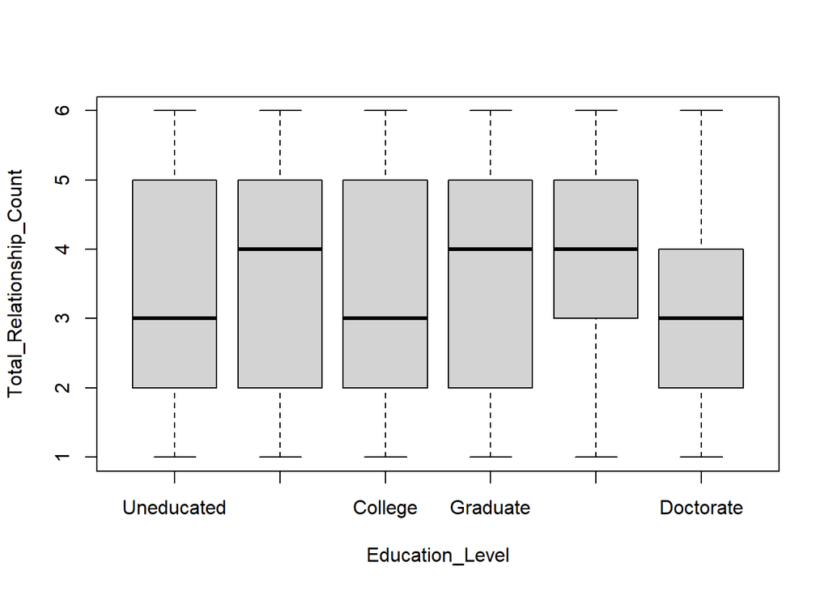

```r
plot(Total_Relationship_Count ~ Education_Level, data=df3)
```

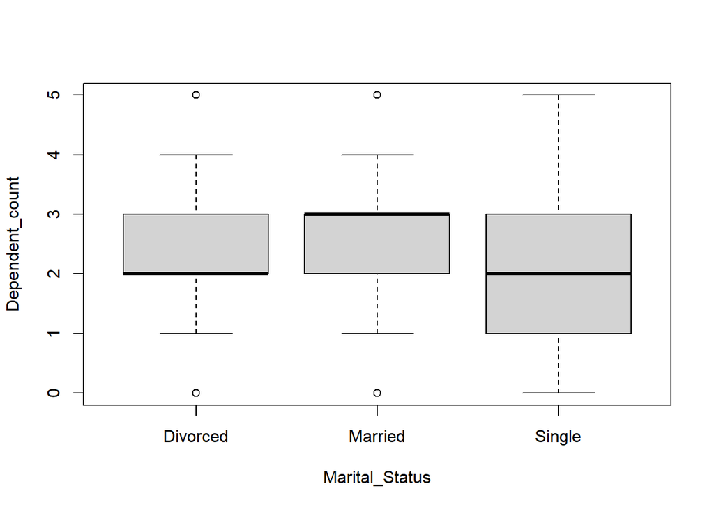

```r
plot(Dependent_count ~ Marital_Status, data=df3)
```

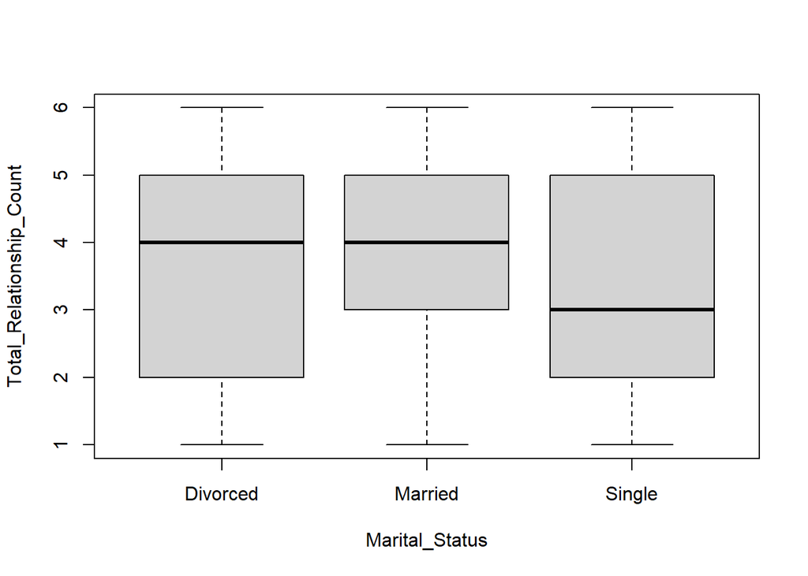

```r
plot(Total_Relationship_Count ~ Marital_Status, data=df3)
```

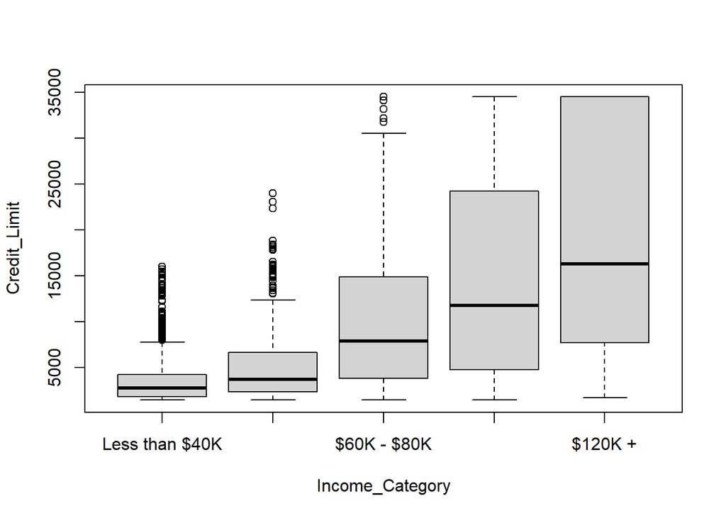

```r
plot(Credit_Limit ~ Income_Category, data=df3)
```

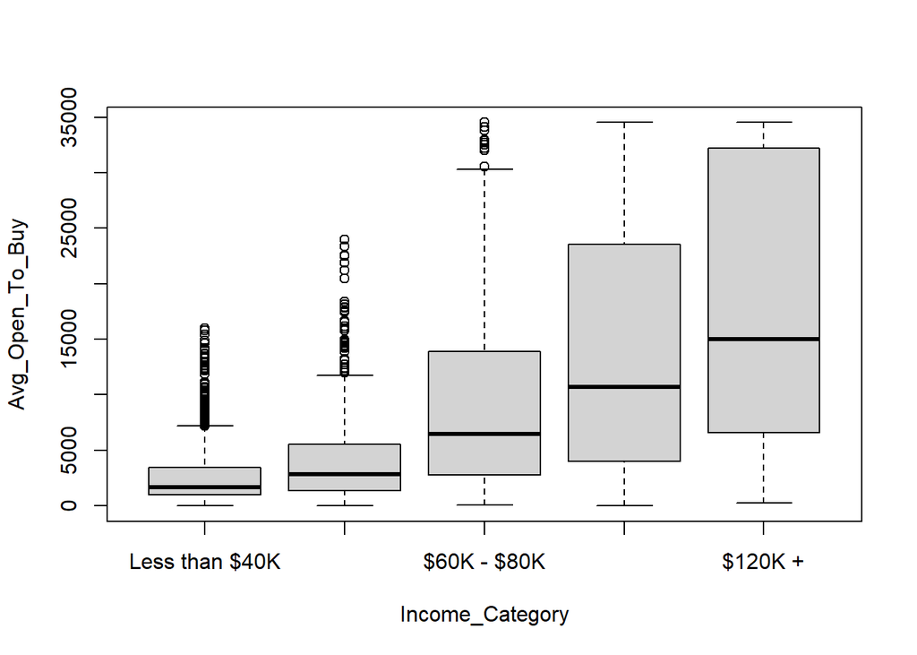

```r
plot(Avg_Open_To_Buy ~ Income_Category, data=df3)
```

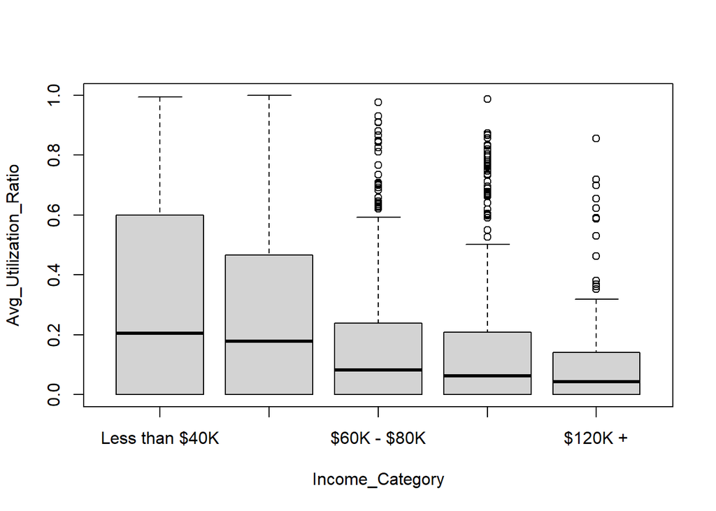

```r
plot(Avg_Utilization_Ratio ~ Income_Category, data=df3)
```

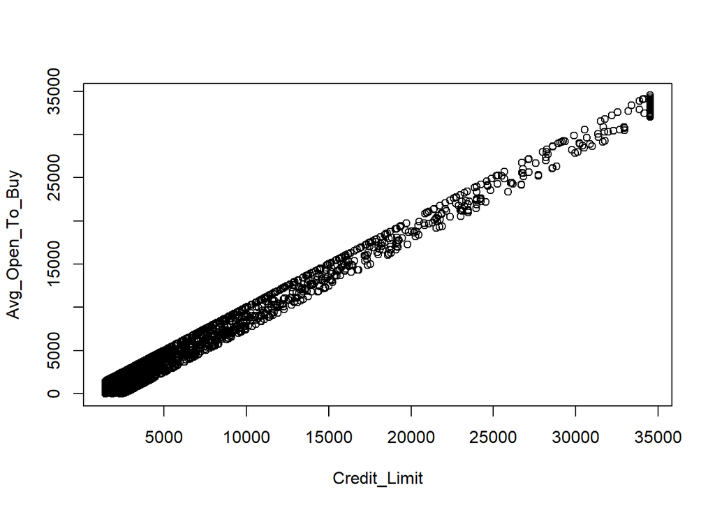

```r
plot(Avg_Open_To_Buy ~ Credit_Limit, data=df3)
```